# Training a Neural Network (1.0 points)

#### Gradient checking:

We are going to use $gradient$ $checking$ to check if the numerical (using approximations) and analytical (computed by our backprop implementation) gradient computations match. To test that we are going to check the gradients computed for a small neural network.

```python
nnodes2 = [2,4,4,2]
activation_functions2 = 'relu'
nnet_checking = NeuralNetwork(nnodes2,activation_functions2)
```

We are going to use a few training examples to check if the analytical and numerical gradients match.

```python
m = 50 # using 50 examples to do gradient checking
train_data = data[1:m]
checkNNGradients(nnet_checking, train_data)  # compute_numerical_gradient
```

```
Relative difference 9.128208913261255e-08 for layer 0 parameters
Analytical and numerical gradients match
as relative distance is less that 1e-5
Relative difference 6.5690655391947615e-09 for layer 1 parameters
Analytical and numerical gradients match
as relative distance is less that 1e-5
Relative difference 1.4487044696481842e-08 for layer 2 parameters
Analytical and numerical gradients match
as relative distance is less that 1e-5
```

### Define a Network

To initialize a Neural Network we must provide two arguments: $nnodes$ and activation_functions. $nnodes$ is a list. Each element of $nnodes$ defines the number of neurons of each layer of the network. By convention the first element of $nnodes$ defines the input layer of the network that is not associated with any weights and biases. The rest of the elements of $nnodes$ are used to initialize the weigths and biases of the hidden layers and the output layer. The activation_functions argument is a string that defines the type of non-linear function to be used for each neuron of the hidden layer. Our implementation supports ReLUs and sigmoids as activation functions. The output layer is set to always be a sigmoid function.

```python
nnodes=[2, 10,10, 2]
activation_functions='sigmoid' # use 'sigmoid' or 'relu'
nnet = NeuralNetwork(nnodes,activation_functions)
#print(nnet.weights) # uncomment to see weights after they have been initialized
```

### Train a network with sigmoid non-linearities across all layers

To train the Network we use the `gradient_descent` method defined inside the `NeuralNetwork` Class

```python
learning_rate=2 #
epochs = 15000  ## usually has already converged around that number
stop = 260 #  number of correctly classified performance to which we wish to stop training / set it to a number close to 300
train_data = data
test_data = data

nnet.gradient_descent(train_data,epochs,learning_rate,stop,test_data)
```

[output not shown]

[output cut: 14945 more lines]

```
Epoch 14985: 255 / 300 Cost: [0.57812347]
Epoch 14986: 255 / 300 Cost: [0.5781144]
Epoch 14987: 255 / 300 Cost: [0.57810533]
Epoch 14988: 255 / 300 Cost: [0.57809626]
Epoch 14989: 255 / 300 Cost: [0.5780872]
Epoch 14990: 255 / 300 Cost: [0.57807813]
Epoch 14991: 255 / 300 Cost: [0.57806906]
Epoch 14992: 255 / 300 Cost: [0.57806]
Epoch 14993: 255 / 300 Cost: [0.57805093]
Epoch 14994: 255 / 300 Cost: [0.57804187]
Epoch 14995: 255 / 300 Cost: [0.5780328]
Epoch 14996: 255 / 300 Cost: [0.57802374]
Epoch 14997: 255 / 300 Cost: [0.57801467]
Epoch 14998: 255 / 300 Cost: [0.57800561]
Epoch 14999: 255 / 300 Cost: [0.57799655]
```

```
best_accuracy: 0.8633333333333333 achieved at epoch: 7576
```

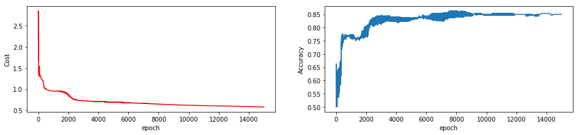

```python
#### RUN this after training is done

# Access the cost and accuracy during training by referencing the nnet object's attributes costs and accuracies
#This is done in the following way:
cost_training = nnet.costs
accuracy_training = nnet.accuracies
# Plots the cost and accuracy evolution during training
fig = plt.figure(figsize=plt.figaspect(0.2))
ax1 = fig.add_subplot(1, 2, 1)
ax1.plot(cost_training,'r')
ax1.set_xlabel('epoch')
ax1.set_ylabel('Cost')
ax2 = fig.add_subplot(1, 2, 2)
ax2.plot(accuracy_training)
ax2.set_xlabel('epoch')
ax2.set_ylabel('Accuracy')
A = np.array(accuracy_training)
best_epoch = np.argmax(A)
print('best_accuracy:', max(accuracy_training), 'achieved at epoch:', best_epoch)
```